# Introdução ao R

# Parte 1

## Capítulo 2.2 - Operadores

### Operadores Aritiméticos

##### Soma

```r
7 + 7
```

```
## [1] 14
```

##### Subtração

```r
7 - 4
```

```
## [1] 3
```

##### Multiplicação

```r
5 * 5
```

```
## [1] 25
```

##### Divisão

```r
6 / 6
```

```
## [1] 1
```

##### Potência

```r
3^2
```

```
## [1] 9
```

```r
3**2
```

```
## [1] 9
```

##### Módulo

```r
16 %% 3
```

```
## [1] 1
```

### Operadores Relacionais

##### Atribuindo variáveis

```r
x = 7
y = 5
```

##### Operadores

```r
x > 8
```

```
## [1] FALSE
```

```r
x < 8
```

```
## [1] TRUE
```

```r
x <= 8
```

```
## [1] TRUE
```

```r
x >= 8
```

```
## [1] FALSE
```

```r
x == 8
```

```
## [1] FALSE
```

```r
x != 8
```

```
## [1] TRUE
```

### Operadores lógicos

##### And

```r
(x==8) & (x==6)
```

```
## [1] FALSE
```

```r
(x==7) & (x>=5)
```

```
## [1] TRUE
```

```r
(x==8) & (x==7)
```

```
## [1] FALSE
```

##### Or

```r
(x==8) | (x>5)
```

```
## [1] TRUE
```

```r
(x==8) | (x>=5)
```

```
## [1] TRUE
```

##### Not

```r
x > 8
```

```
## [1] FALSE
```

```r
print(!x > 8)
```

```
## [1] TRUE
```

## Capítulo 2.3 - Variáveis

### Criando Variáveis

```r
var1 = 100
var1
```

```
## [1] 100
```

```r
mode(var1)
```

```
## [1] "numeric"
```

```r
sqrt(var1)
```

```
## [1] 10
```

```r
help("mode")
```

##### Podemos atribuir o valor de uma variável a outra variável

```r
var2 = var1
var2
```

```
## [1] 100
```

```r
mode(var2)
```

```
## [1] "numeric"
```

```r
typeof(var2)
```

```
## [1] "double"
```

```r
help("typeof")
```

##### Uma variável pode ser uma lista de elementos

```r
var3 = c("primeiro", "segundo", "terceiro")
var3
```

```
## [1] "primeiro" "segundo"  "terceiro"
```

```r
mode(var3)
```

```
## [1] "character"
```

##### Uma variável pode ser uma função

```r
var4 = function(x) {x+3}
var4
```

```
## function(x) {x+3}
```

```r
mode(var4)
```

```
## [1] "function"
```

##### Podemos também mudar o modo do dado.

```r
var5 = as.character(var1)
var5
```

```
## [1] "100"
```

```r
mode(var5)
```

```
## [1] "character"
```

##### Atribuindo valores a objetos

```r
x <- c(1,2,3)
x
```

```
## [1] 1 2 3
```

```r
x1 = c(1,2,3)
x1
```

```
## [1] 1 2 3
```

```r
c(1,2,3) -> y
y
```

```
## [1] 1 2 3
```

```r
assign("x", c(6.3,4,-2))
x
```

```
## [1]  6.3  4.0 -2.0
```

##### Verificando o valor em uma posição específica

```r
x[1]
```

```
## [1] 6.3
```

##### Verificar objetos

```r
ls()
```

```
## [1] "var1" "var2" "var3" "var4" "var5" "x"    "x1"   "y"
```

```r
objects()
```

```
## [1] "var1" "var2" "var3" "var4" "var5" "x"    "x1"   "y"
```

## Capítulo 2.4 - Tipos de Dados

##### Numeric - Todos os números criados em R são do modo numeric

##### São armazenados como números decimais (double)

```r
num1 <- 7
num1
```

```
## [1] 7
```

```r
class(num1)
```

```
## [1] "numeric"
```

```r
mode(num1)
```

```
## [1] "numeric"
```

```r
typeof(num1)
```

```
## [1] "double"
```

```r
num2 = 16.82
num2
```

```
## [1] 16.82
```

```r
mode(num2)
```

```
## [1] "numeric"
```

```r
typeof(num2)
```

```
## [1] "double"
```

##### Convertemos tipos numeric para integer

```r
is.integer(num2)
```

```
## [1] FALSE
```

```r
y = as.integer(num2)
y
```

```
## [1] 16
```

```r
class(y)
```

```
## [1] "integer"
```

```r
mode(y)
```

```
## [1] "numeric"
```

```r
typeof(y)
```

```
## [1] "integer"
```

```r
as.integer('3.17')
```

```
## [1] 3
```

```r
as.integer("Joe")
```

```
## [1] NA
```

```r
as.integer('Joe')
```

```
## [1] NA
```

```r
as.integer(TRUE)
```

```
## [1] 1
```

```r
as.integer(FALSE)
```

```
## [1] 0
```

```r
as.integer('TRUE')
```

```
## [1] NA
```

##### Character

```r
char1 = 'A'
char1
```

```
## [1] "A"
```

```r
mode(char1)
```

```
## [1] "character"
```

```r
typeof(char1)
```

```
## [1] "character"
```

```r
char2 = "cientista"
char2
```

```
## [1] "cientista"
```

```r
mode(char2)
```

```
## [1] "character"
```

```r
typeof(char2)
```

```
## [1] "character"
```

```r
char3 = c("Data", "Scicence", "Academy")
char3
```

```
## [1] "Data"     "Scicence" "Academy"
```

```r
mode(char3)
```

```
## [1] "character"
```

```r
typeof(char3)
```

```
## [1] "character"
```

##### Complex

```r
compl = 2.5 + 4i
compl
```

```
## [1] 2.5+4i
```

```r
mode(compl)
```

```
## [1] "complex"
```

```r
typeof(compl)
```

```
## [1] "complex"
```

```r
sqrt(-1)
```

```
## [1] NaN
```

```r
sqrt(-1+0i)
```

```
## [1] 0+1i
```

```r
sqrt(as.complex(-1))
```

```
## [1] 0+1i
```

##### Logic

```r
x = 1; y = 2
z = x > y
z
```

```
## [1] FALSE
```

```r
class(z)
```

```
## [1] "logical"
```

```r
u = TRUE; v = FALSE
class(u)
```

```
## [1] "logical"
```

```r
u & v
```

```
## [1] FALSE
```

```r
u | v
```

```
## [1] TRUE
```

```r
!u
```

```
## [1] FALSE
```

##### Operações com 0

```r
5/0
```

```
## [1] Inf
```

```r
0/5
```

```
## [1] 0
```

##### Erro

```r
'Joe'/5
```

## Capítulo 2.5 - Tipos de Dados Avaçados

##### Vetor: possui 1 dimensão e 1 tipo de dado

```r
vetor1 <- c(1:20)
vetor1
```

```
##  [1]  1  2  3  4  5  6  7  8  9 10 11 12 13 14 15 16 17 18 19 20
```

```r
length(vetor1)
```

```
## [1] 20
```

```r
mode(vetor1)
```

```
## [1] "numeric"
```

```r
class(vetor1)
```

```
## [1] "integer"
```

```r
typeof(vetor1)
```

```
## [1] "integer"
```

##### Matriz: possui 2 dimensões e 1 tipo de dado

```r
matriz1 <- matrix(1:20, nrow = 2)
matriz1
```

```
##      [,1] [,2] [,3] [,4] [,5] [,6] [,7] [,8] [,9] [,10]
## [1,]    1    3    5    7    9   11   13   15   17    19
## [2,]    2    4    6    8   10   12   14   16   18    20
```

```r
length(matriz1)
```

```
## [1] 20
```

```r
mode(matriz1)
```

```
## [1] "numeric"
```

```r
class(matriz1)
```

```
## [1] "matrix" "array"
```

```r
typeof(matriz1)
```

```
## [1] "integer"
```

##### Array: possui 2 ou mais dimensões e 1 tipo de dado

```r
array1 <- array(1:5, dim = c(3,3,3))
array1
```

```
## , , 1
##
##      [,1] [,2] [,3]
## [1,]    1    4    2
## [2,]    2    5    3
## [3,]    3    1    4
##
## , , 2
##
##      [,1] [,2] [,3]
## [1,]    5    3    1
## [2,]    1    4    2
## [3,]    2    5    3
##
## , , 3
##
##      [,1] [,2] [,3]
## [1,]    4    2    5
## [2,]    5    3    1
## [3,]    1    4    2
```

```r
length(array1)
```

```
## [1] 27
```

```r
mode(array1)
```

```
## [1] "numeric"
```

```r
class(array1)
```

```
## [1] "array"
```

```r
typeof(array1)
```

```
## [1] "integer"
```

##### Data Frames: dados de diferentes tipos

##### Maneira mais fácil de explicar data frames: é uma matriz com diferentes tipos de dados

```r
View(iris)
length(iris)
```

```
## [1] 5
```

```r
mode(iris)
```

```
## [1] "list"
```

```r
class(iris)
```

```
## [1] "data.frame"
```

```r
typeof(iris)
```

```
## [1] "list"
```

##### Listas: coleção de diferentes objetos

##### Diferentes tipos de dados são possíveis e comuns

```r
lista1 <- list(a = matriz1, b = vetor1)
lista1
```

```
## $a
##      [,1] [,2] [,3] [,4] [,5] [,6] [,7] [,8] [,9] [,10]
## [1,]    1    3    5    7    9   11   13   15   17    19
## [2,]    2    4    6    8   10   12   14   16   18    20
##
## $b
##  [1]  1  2  3  4  5  6  7  8  9 10 11 12 13 14 15 16 17 18 19 20
```

```r
length(lista1)
```

```
## [1] 2
```

```r
mode(lista1)
```

```
## [1] "list"
```

```r
class(lista1)
```

```
## [1] "list"
```

```r
typeof(lista1)
```

```
## [1] "list"
```

##### Funções também são vistas como objetos em R

```r
func1 <- function(x) {
  var1 <- x * x
  return(var1)
}

func1(5)
```

```
## [1] 25
```

```r
class(func1)
```

```
## [1] "function"
```

##### Removendo objetos

```r
objects()
```

```
##  [1] "array1"  "char1"   "char2"   "char3"   "compl"   "func1"   "lista1"
##  [8] "matriz1" "num1"    "num2"    "u"       "v"       "var1"    "var2"
## [15] "var3"    "var4"    "var5"    "vetor1"  "x"       "x1"      "y"
## [22] "z"
```

```r
rm(array1, func1)
objects()
```

```
##  [1] "char1"   "char2"   "char3"   "compl"   "lista1"  "matriz1" "num1"
##  [8] "num2"    "u"       "v"       "var1"    "var2"    "var3"    "var4"
## [15] "var5"    "vetor1"  "x"       "x1"      "y"       "z"
```

## Capítulo 2.6 - Vetores

##### Vetor de strings

```r
vetor_caracter = c("Data", "Science", "Academy")
vetor_caracter
```

```
## [1] "Data"    "Science" "Academy"
```

##### Vetor de floats

```r
vetor_numerico = c(1.90, 45.3, 300.5)
vetor_numerico
```

```
## [1]   1.9  45.3 300.5
```

##### Vetor de valores complexos

```r
vetor_complexo = c(5.2+3i, 3.8+4i)
vetor_complexo
```

```
## [1] 5.2+3i 3.8+4i
```

##### Vetor de valores lógicos

```r
vetor_logico = c(TRUE, FALSE, TRUE, FALSE, FALSE)
vetor_logico
```

```
## [1]  TRUE FALSE  TRUE FALSE FALSE
```

```r
vetor_integer  = c(2, 4, 6)
vetor_integer
```

```
## [1] 2 4 6
```

##### Utilizando seq()

```r
vetor1 = seq(1:10)
vetor1
```

```
##  [1]  1  2  3  4  5  6  7  8  9 10
```

```r
is.vector(vetor1)
```

```
## [1] TRUE
```

##### Utilizando rep()

```r
vetor2 = rep(1:5)
vetor2
```

```
## [1] 1 2 3 4 5
```

```r
is.vector(vetor2)
```

```
## [1] TRUE
```

```r
pi:10
```

```
## [1] 3.141593 4.141593 5.141593 6.141593 7.141593 8.141593 9.141593
```

##### Indexação de vetores

```r
a <- c(1,2,3,4,5)
a
```

```
## [1] 1 2 3 4 5
```

```r
a[1]
```

```
## [1] 1
```

```r
a[6]
```

```
## [1] NA
```

```r
b <- c("Data", "Science", "Academy")
b
```

```
## [1] "Data"    "Science" "Academy"
```

```r
b[1]
```

```
## [1] "Data"
```

```r
b[2]
```

```
## [1] "Science"
```

```r
b[3]
```

```
## [1] "Academy"
```

```r
b[4]
```

```
## [1] NA
```

##### Combinando vetores

```r
v1 = c(2, 3, 5)
v2 = c("aa", "bb", "cc", "dd", "ee")
c(v1, v2)
```

```
## [1] "2"  "3"  "5"  "aa" "bb" "cc" "dd" "ee"
```

##### Operações com Vetores

```r
x = c(1, 3, 5, 7)
y = c(2, 4, 6, 8)

x * 5
```

```
## [1]  5 15 25 35
```

```r
x + y
```

```
## [1]  3  7 11 15
```

```r
x - y
```

```
## [1] -1 -1 -1 -1
```

```r
x * y
```

```
## [1]  2 12 30 56
```

```r
x / y
```

```
## [1] 0.5000000 0.7500000 0.8333333 0.8750000
```

##### Somando vetores com números diferentes de elementos

```r
alfa = c(10, 20, 30)
beta = c(1, 2, 3, 4, 5, 6, 7, 8, 9)
alfa + beta
```

```
## [1] 11 22 33 14 25 36 17 28 39
```

##### Vetor Nomeado

```r
v = c("Nelson", "Mandela")
v
```

```
## [1] "Nelson"  "Mandela"
```

```r
names(v) = c("Nome", "Sobrenome")
v
```

```
##      Nome Sobrenome
##  "Nelson" "Mandela"
```

```r
v["Nome"]
```

```
##     Nome
## "Nelson"
```

## Capítulo 2.7 - Matrizes

##### Número de Linhas

```r
matrix (c(1,2,3,4,5,6), nr = 2)
```

```
##      [,1] [,2] [,3]
## [1,]    1    3    5
## [2,]    2    4    6
```

```r
matrix (c(1,2,3,4,5,6), nr = 3)
```

```
##      [,1] [,2]
## [1,]    1    4
## [2,]    2    5
## [3,]    3    6
```

```r
matrix (c(1,2,3,4,5,6), nr = 6)
```

```
##      [,1]
## [1,]    1
## [2,]    2
## [3,]    3
## [4,]    4
## [5,]    5
## [6,]    6
```

##### Número de Colunas

```r
matrix (c( 1,2,3,4,5,6), nc = 2)
```

```
##      [,1] [,2]
## [1,]    1    4
## [2,]    2    5
## [3,]    3    6
```

##### Help

```r
?matrix
```

##### Matrizes precisam ter um número de elementos que seja múltiplo do número de linhas

```r
matrix (c(1,2,3,4,5), nc = 2)
```

```
##      [,1] [,2]
## [1,]    1    4
## [2,]    2    5
## [3,]    3    1
```

##### Criando matrizes a partir de vetores e preenchendo a partir das linhas

```r
meus_dados = c(1:10)
matrix(data = meus_dados, nrow = 5, ncol = 2, byrow = T)
```

```
##      [,1] [,2]
## [1,]    1    2
## [2,]    3    4
## [3,]    5    6
## [4,]    7    8
## [5,]    9   10
```

```r
matrix(data = meus_dados, nrow = 5, ncol = 2)
```

```
##      [,1] [,2]
## [1,]    1    6
## [2,]    2    7
## [3,]    3    8
## [4,]    4    9
## [5,]    5   10
```

##### Fatiando a Matriz

```r
mat <- matrix(c(2,3,4,5), nr = 2)
mat
```

```
##      [,1] [,2]
## [1,]    2    4
## [2,]    3    5
```

```r
mat[1,2]
```

```
## [1] 4
```

```r
mat[2,2]
```

```
## [1] 5
```

```r
##### mat[1,3]
mat[,2]
```

```
## [1] 4 5
```

##### Criando uma matriz diagonal

```r
matriz = 1:3
diag(matriz)
```

```
##      [,1] [,2] [,3]
## [1,]    1    0    0
## [2,]    0    2    0
## [3,]    0    0    3
```

##### Extraindo vetor de uma matriz diagonal

```r
vetor = diag(matriz)
diag(vetor)
```

```
## [1] 1 2 3
```

##### Transposta da matriz

```r
W <- matrix (c(2,4,8,12 ), nr = 2, ncol = 2)
W
```

```
##      [,1] [,2]
## [1,]    2    8
## [2,]    4   12
```

```r
t(W)
```

```
##      [,1] [,2]
## [1,]    2    4
## [2,]    8   12
```

```r
U <- t(W)
U
```

```
##      [,1] [,2]
## [1,]    2    4
## [2,]    8   12
```

##### Obtendo uma matriz inversa

```r
solve(W)
```

```
##      [,1]  [,2]
## [1,] -1.5  1.00
## [2,]  0.5 -0.25
```

##### Multiplicação de Matrizes

```r
mat1 <- matrix(c(2,3,4,5), nr = 2)
mat1
```

```
##      [,1] [,2]
## [1,]    2    4
## [2,]    3    5
```

```r
mat2 <- matrix(c(6,7,8,9), nr = 2)
mat2
```

```
##      [,1] [,2]
## [1,]    6    8
## [2,]    7    9
```

```r
mat1 * mat2
```

```
##      [,1] [,2]
## [1,]   12   32
## [2,]   21   45
```

```r
mat1 / mat2
```

```
##           [,1]      [,2]
## [1,] 0.3333333 0.5000000
## [2,] 0.4285714 0.5555556
```

```r
mat1 + mat2
```

```
##      [,1] [,2]
## [1,]    8   12
## [2,]   10   14
```

```r
mat1 - mat2
```

```
##      [,1] [,2]
## [1,]   -4   -4
## [2,]   -4   -4
```

##### Multiplicando Matriz com Vetor

```r
x = c(1:4)
x
```

```
## [1] 1 2 3 4
```

```r
y <- matrix(c(2,3,4,5), nr = 2)
x * y
```

```
##      [,1] [,2]
## [1,]    2   12
## [2,]    6   20
```

##### Nomeando a Matriz

```r
mat3 <- matrix(c('Terra', 'Marte', 'Saturno', 'Netuno'), nr = 2)
mat3
```

```
##      [,1]    [,2]
## [1,] "Terra" "Saturno"
## [2,] "Marte" "Netuno"
```

```r
dimnames(mat3) = (list( c("Linha1", "Linha2"), c("Coluna1", "Coluna2")))
mat3
```

```
##        Coluna1 Coluna2
## Linha1 "Terra" "Saturno"
## Linha2 "Marte" "Netuno"
```

##### Identificando linhas e colunas no momento de criação da Matriz

```r
matrix (c(1,2,3,4), nr = 2, nc = 2, dimnames = list(c("Linha 1", "Linha 2" ), c( "Coluna 1", " Coluna 2") ))
```

```
##         Coluna 1  Coluna 2
## Linha 1        1         3
## Linha 2        2         4
```

##### Combinando Matrizes

```r
mat4 <- matrix(c(2,3,4,5), nr = 2)
mat4
```

```
##      [,1] [,2]
## [1,]    2    4
## [2,]    3    5
```

```r
mat5 <- matrix(c(6,7,8,9), nr = 2)
mat5
```

```
##      [,1] [,2]
## [1,]    6    8
## [2,]    7    9
```

```r
cbind(mat4, mat5)
```

```
##      [,1] [,2] [,3] [,4]
## [1,]    2    4    6    8
## [2,]    3    5    7    9
```

```r
rbind(mat4, mat5)
```

```
##      [,1] [,2]
## [1,]    2    4
## [2,]    3    5
## [3,]    6    8
## [4,]    7    9
```

##### Desconstruindo a Matriz

```r
c(mat4)
```

```
## [1] 2 3 4 5
```

## Capítulo 2.8 - Listas

##### Use list() para criar listas

##### Lista de strings

```r
lista_caracter1 = list('A', 'B', 'C')
lista_caracter1
```

```
## [[1]]
## [1] "A"
##
## [[2]]
## [1] "B"
##
## [[3]]
## [1] "C"
```

```r
lista_caracter2 = list(c("A", "A"), 'B', 'C')
lista_caracter2
```

```
## [[1]]
## [1] "A" "A"
##
## [[2]]
## [1] "B"
##
## [[3]]
## [1] "C"
```

```r
lista_caracter3 = list(matrix(c("A", "A", "A", "A"), nr = 2), 'B', 'C')
lista_caracter3
```

```
## [[1]]
##      [,1] [,2]
## [1,] "A"  "A"
## [2,] "A"  "A"
##
## [[2]]
## [1] "B"
##
## [[3]]
## [1] "C"
```

##### Lista de números inteiros

```r
lista_inteiros = list(2, 3, 4)
lista_inteiros
```

```
## [[1]]
## [1] 2
##
## [[2]]
## [1] 3
##
## [[3]]
## [1] 4
```

##### Lista de floats

```r
lista_numerico = list(1.90, 45.3, 300.5)
lista_numerico
```

```
## [[1]]
## [1] 1.9
##
## [[2]]
## [1] 45.3
##
## [[3]]
## [1] 300.5
```

##### Lista de números complexos

```r
lista_complexos = list(5.2+3i, 2.4+8i)
lista_complexos
```

```
## [[1]]
## [1] 5.2+3i
##
## [[2]]
## [1] 2.4+8i
```

##### Lista de valores lógicos

```r
lista_logicos = list(TRUE, FALSE, FALSE)
lista_logicos
```

```
## [[1]]
## [1] TRUE
##
## [[2]]
## [1] FALSE
##
## [[3]]
## [1] FALSE
```

##### Listas Compostas

```r
lista_composta1 = list("A", 3, TRUE)
lista_composta1
```

```
## [[1]]
## [1] "A"
##
## [[2]]
## [1] 3
##
## [[3]]
## [1] TRUE
```

```r
lista1 <- list(1:10, c("Zico", "Ronaldo", "Garrincha"), rnorm(10))
lista1
```

```
## [[1]]
##  [1]  1  2  3  4  5  6  7  8  9 10
##
## [[2]]
## [1] "Zico"      "Ronaldo"   "Garrincha"
##
## [[3]]
##  [1]  0.05480752  0.08398292  1.21616226  0.46928663  0.23950256 -0.46649841
##  [7] -0.41758388  0.50731574 -0.86592023 -0.81660741
```

```r
?rnorm
```

##### Slicing (Fatiamento) da Lista

```r
lista1
```

```
## [[1]]
##  [1]  1  2  3  4  5  6  7  8  9 10
##
## [[2]]
## [1] "Zico"      "Ronaldo"   "Garrincha"
##
## [[3]]
##  [1]  0.05480752  0.08398292  1.21616226  0.46928663  0.23950256 -0.46649841
##  [7] -0.41758388  0.50731574 -0.86592023 -0.81660741
```

```r
lista1[1]
```

```
## [[1]]
##  [1]  1  2  3  4  5  6  7  8  9 10
```

```r
lista1[2]
```

```
## [[1]]
## [1] "Zico"      "Ronaldo"   "Garrincha"
```

```r
lista1[[2]][1]
```

```
## [1] "Zico"
```

```r
lista1[[2]][1] = "Monica"
lista1
```

```
## [[1]]
##  [1]  1  2  3  4  5  6  7  8  9 10
##
## [[2]]
## [1] "Monica"    "Ronaldo"   "Garrincha"
##
## [[3]]
##  [1]  0.05480752  0.08398292  1.21616226  0.46928663  0.23950256 -0.46649841
##  [7] -0.41758388  0.50731574 -0.86592023 -0.81660741
```

##### Para nomear os elementos - Listas Nomeadas

```r
names(lista1) <- c("inteiros", "caracteres", "numéricos")
lista1
```

```
## $inteiros
##  [1]  1  2  3  4  5  6  7  8  9 10
##
## $caracteres
## [1] "Monica"    "Ronaldo"   "Garrincha"
##
## $numéricos
##  [1]  0.05480752  0.08398292  1.21616226  0.46928663  0.23950256 -0.46649841
##  [7] -0.41758388  0.50731574 -0.86592023 -0.81660741
```

```r
vec_num <- 1:4
vec_char <- c("A", "B", "C", "D")

lista2 <- list(Numeros = vec_num, Letras = vec_char)
lista2
```

```
## $Numeros
## [1] 1 2 3 4
##
## $Letras
## [1] "A" "B" "C" "D"
```

```r
lista2$Letras[1]
```

```
## [1] "A"
```

##### Nomear os elementos diretamente

```r
lista2 <- list(elemento1 = 3:5, elemento2 = c(7.2,3.5))
lista2
```

```
## $elemento1
## [1] 3 4 5
##
## $elemento2
## [1] 7.2 3.5
```

##### Trabalhando com elementos específicos da lista

```r
names(lista1) <- c("inteiros", "caracteres", "numéricos")
lista1
```

```
## $inteiros
##  [1]  1  2  3  4  5  6  7  8  9 10
##
## $caracteres
## [1] "Monica"    "Ronaldo"   "Garrincha"
##
## $numéricos
##  [1]  0.05480752  0.08398292  1.21616226  0.46928663  0.23950256 -0.46649841
##  [7] -0.41758388  0.50731574 -0.86592023 -0.81660741
```

```r
lista1$caracteres
```

```
## [1] "Monica"    "Ronaldo"   "Garrincha"
```

```r
length(lista1$inteiros)
```

```
## [1] 10
```

```r
lista1$inteiros
```

```
##  [1]  1  2  3  4  5  6  7  8  9 10
```

##### Verificar o comprimento da lista

```r
length(lista1)
```

```
## [1] 3
```

##### Podemos extrair um elemento específico dentro de cada nível da lista

```r
lista1$caracteres[2]
```

```
## [1] "Ronaldo"
```

##### Mode dos elementos

```r
mode(lista1$numéricos)
```

```
## [1] "numeric"
```

```r
mode(lista1$caracteres)
```

```
## [1] "character"
```

##### Combinando 2 listas

```r
lista3 <- c(lista1, lista2)
lista3
```

```
## $inteiros
##  [1]  1  2  3  4  5  6  7  8  9 10
##
## $caracteres
## [1] "Monica"    "Ronaldo"   "Garrincha"
##
## $numéricos
##  [1]  0.05480752  0.08398292  1.21616226  0.46928663  0.23950256 -0.46649841
##  [7] -0.41758388  0.50731574 -0.86592023 -0.81660741
##
## $elemento1
## [1] 3 4 5
##
## $elemento2
## [1] 7.2 3.5
```

##### Transformando um vetor em lista

```r
v = c(1:3)
v
```

```
## [1] 1 2 3
```

```r
mode(v)
```

```
## [1] "numeric"
```

```r
l  = as.list(v)
l
```

```
## [[1]]
## [1] 1
##
## [[2]]
## [1] 2
##
## [[3]]
## [1] 3
```

```r
l[[1]][1]
```

```
## [1] 1
```

```r
l[[1]]
```

```
## [1] 1
```

##### Unindo 2 elementos em uma lista

```r
mat = matrix(1:4, nrow = 2)
mat
```

```
##      [,1] [,2]
## [1,]    1    3
## [2,]    2    4
```

```r
vec = c(1:9)
vec
```

```
## [1] 1 2 3 4 5 6 7 8 9
```

```r
lst = list(mat, vec)
lst
```

```
## [[1]]
##      [,1] [,2]
## [1,]    1    3
## [2,]    2    4
##
## [[2]]
## [1] 1 2 3 4 5 6 7 8 9
```

## Capítulo 2.9 - String

##### String

```r
texto <- "Isso é uma string!"
texto
```

```
## [1] "Isso é uma string!"
```

```r
x = as.character(3.14)
x
```

```
## [1] "3.14"
```

```r
class(x)
```

```
## [1] "character"
```

##### Concatenando Strings

```r
nome = "Nelson"; sobrenome = "Mandela"
paste(nome, sobrenome)
```

```
## [1] "Nelson Mandela"
```

```r
# cat will not return anything, it will just output to the console or another connection.
cat(nome, sobrenome)
```

```
## Nelson Mandela
```

##### Formatando a saída

```r
sprintf("A %s é nota %d", "Data Science Academy", 10)
```

```
## [1] "A Data Science Academy é nota 10"
```

##### Extraindo parte da string

```r
texto <- "Isso é uma string!"
substr(texto, start=12, stop=17)
```

```
## [1] "string"
```

```r
?substr
```

##### Contando o número de caracteres

```r
nchar(texto)
```

```
## [1] 18
```

##### Alterando a capitalização

```r
tolower("Histogramas e Elementos de Dados")
```

```
## [1] "histogramas e elementos de dados"
```

```r
toupper("Histogramas e Elementos de Dados")
```

```
## [1] "HISTOGRAMAS E ELEMENTOS DE DADOS"
```

##### Usando stringr

```r
library(stringr)
```

##### Dividindo uma string em caracteres

```r
?strsplit
```

```r
strsplit("Histogramas e Elementos de Dados", NULL)
```

```
## [[1]]
##  [1] "H" "i" "s" "t" "o" "g" "r" "a" "m" "a" "s" " " "e" " " "E" "l" "e" "m" "e"
## [20] "n" "t" "o" "s" " " "d" "e" " " "D" "a" "d" "o" "s"
```

##### Dividindo uma string em caracteres, após o caracter espaço

```r
strsplit("Histogramas e Elementos de Dados", " ")
```

```
## [[1]]
## [1] "Histogramas" "e"           "Elementos"   "de"          "Dados"
```

##### Trabalhando com strings

```r
string1 <- c("Esta é a primeira parte da minha string e será a primeira parte do meu vetor",
             "Aqui a minha string continua, mas será transformada no segundo vetor")

string1
```

```
## [1] "Esta é a primeira parte da minha string e será a primeira parte do meu vetor"
## [2] "Aqui a minha string continua, mas será transformada no segundo vetor"
```

```r
string2 <- c("Precisamos testar outras strings - @???!§$",
             "Análise de Dados em R")

string2
```

```
## [1] "Precisamos testar outras strings - @???!§$"
## [2] "Análise de Dados em R"
```

##### Adicionando 2 strings

```r
str_c(c(string1, string2), sep = "")
```

```
## [1] "Esta é a primeira parte da minha string e será a primeira parte do meu vetor"
## [2] "Aqui a minha string continua, mas será transformada no segundo vetor"
## [3] "Precisamos testar outras strings - @???!§$"
## [4] "Análise de Dados em R"
```

##### Podemos contar quantas vezes um caracter aparece no texto

```r
str_count(string2, "s")
```

```
## [1] 6 2
```

##### Localiza a primeira e última posição em que o caracter aparece na string

```r
str_locate_all(string2, "s")
```

```
## [[1]]
##      start end
## [1,]     6   6
## [2,]    10  10
## [3,]    14  14
## [4,]    24  24
## [5,]    26  26
## [6,]    32  32
##
## [[2]]
##      start end
## [1,]     6   6
## [2,]    16  16
```

##### Substitui a primeira ocorrência de um caracter

```r
str_replace(string2, "\\s", "")
```

```
## [1] "Precisamostestar outras strings - @???!§$"
## [2] "Análisede Dados em R"
```

##### Substitui todas as ocorrências de um caracter

```r
str_replace_all(string2, "\\s", "")
```

```
## [1] "Precisamostestaroutrasstrings-@???!§$"
## [2] "AnálisedeDadosemR"
```

##### Detectando padrões nas strings

```r
string1 <- "17 jan 2001"
string2 <- "1 jan 2001"
padrao <- "jan 20"
grepl(pattern = padrao, x = string1)
```

```
## [1] TRUE
```

```r
padrao <- "jan20"
grepl(pattern = padrao, x = string1)
```

```
## [1] FALSE
```

## Capítulo 2.10 - Dataframes

##### Criando um dataframe vazio

```r
df <- data.frame()
class(df)
```

```
## [1] "data.frame"
```

```r
df
```

```
## data frame with 0 columns and 0 rows
```

##### Criando vetores vazios

```r
nomes <- character()
idades <- numeric()
itens <- numeric()
codigos <- integer()

df <- data.frame(c(nomes, idades, itens, codigos))
df
```

```
## [1] c.nomes..idades..itens..codigos.
## <0 rows> (or 0-length row.names)
```

```r
# Para ver o conteudo do dataframe
View(df)
```

##### Criando vetores

```r
pais = c("Portugal", "Inglaterra", "Irlanda", "Egito", "Brasil")
nome = c("Bruno", "Tiago", "Amanda", "Bianca", "Marta")
altura = c(1.88, 1.76, 1.53, 1.69, 1.68)
codigo = c(5001, 2183, 4702, 7965, 8890)
```

##### Criando um dataframe de diversos vetores

```r
pesquisa = data.frame(pais, nome, altura, codigo)
pesquisa
```

```
##         pais   nome altura codigo
## 1   Portugal  Bruno   1.88   5001
## 2 Inglaterra  Tiago   1.76   2183
## 3    Irlanda Amanda   1.53   4702
## 4      Egito Bianca   1.69   7965
## 5     Brasil  Marta   1.68   8890
```

##### Adicionando um novo vetor a um dataframe existente

```r
olhos = c("verde", "azul", "azul", "castanho", "castanho")
pesq = cbind(pesquisa, olhos)
pesq
```

```
##         pais   nome altura codigo    olhos
## 1   Portugal  Bruno   1.88   5001    verde
## 2 Inglaterra  Tiago   1.76   2183     azul
## 3    Irlanda Amanda   1.53   4702     azul
## 4      Egito Bianca   1.69   7965 castanho
## 5     Brasil  Marta   1.68   8890 castanho
```

##### Informações sobre o dataframe

```r
str(pesq)
```

```
## 'data.frame':    5 obs. of  5 variables:
##  $ pais  : chr  "Portugal" "Inglaterra" "Irlanda" "Egito" ...
##  $ nome  : chr  "Bruno" "Tiago" "Amanda" "Bianca" ...
##  $ altura: num  1.88 1.76 1.53 1.69 1.68
##  $ codigo: num  5001 2183 4702 7965 8890
##  $ olhos : chr  "verde" "azul" "azul" "castanho" ...
```

```r
dim(pesq)
```

```
## [1] 5 5
```

```r
length(pesq)
```

```
## [1] 5
```

##### Obtendo um vetor de um dataframe

```r
pesq$pais
```

```
## [1] "Portugal"   "Inglaterra" "Irlanda"    "Egito"      "Brasil"
```

```r
pesq$nome
```

```
## [1] "Bruno"  "Tiago"  "Amanda" "Bianca" "Marta"
```

##### Extraindo um único valor

```r
pesq[1,1]
```

```
## [1] "Portugal"
```

```r
pesq[3,2]
```

```
## [1] "Amanda"
```

##### Número de Linhas e Colunas

```r
nrow(pesq)
```

```
## [1] 5
```

```r
ncol(pesq)
```

```
## [1] 5
```

##### Primeiros elementos do dataframe

```r
head(pesq)
```

```
##         pais   nome altura codigo    olhos
## 1   Portugal  Bruno   1.88   5001    verde
## 2 Inglaterra  Tiago   1.76   2183     azul
## 3    Irlanda Amanda   1.53   4702     azul
## 4      Egito Bianca   1.69   7965 castanho
## 5     Brasil  Marta   1.68   8890 castanho
```

```r
head(mtcars)
```

```
##                    mpg cyl disp  hp drat    wt  qsec vs am gear carb
## Mazda RX4         21.0   6  160 110 3.90 2.620 16.46  0  1    4    4
## Mazda RX4 Wag     21.0   6  160 110 3.90 2.875 17.02  0  1    4    4
## Datsun 710        22.8   4  108  93 3.85 2.320 18.61  1  1    4    1
## Hornet 4 Drive    21.4   6  258 110 3.08 3.215 19.44  1  0    3    1
## Hornet Sportabout 18.7   8  360 175 3.15 3.440 17.02  0  0    3    2
## Valiant           18.1   6  225 105 2.76 3.460 20.22  1  0    3    1
```

##### Últimos elementos do dataframe

```r
tail(pesq)
```

```
##         pais   nome altura codigo    olhos
## 1   Portugal  Bruno   1.88   5001    verde
## 2 Inglaterra  Tiago   1.76   2183     azul
## 3    Irlanda Amanda   1.53   4702     azul
## 4      Egito Bianca   1.69   7965 castanho
## 5     Brasil  Marta   1.68   8890 castanho
```

```r
tail(mtcars)
```

```
##                 mpg cyl  disp  hp drat    wt qsec vs am gear carb
## Porsche 914-2  26.0   4 120.3  91 4.43 2.140 16.7  0  1    5    2
## Lotus Europa   30.4   4  95.1 113 3.77 1.513 16.9  1  1    5    2
## Ford Pantera L 15.8   8 351.0 264 4.22 3.170 14.5  0  1    5    4
## Ferrari Dino   19.7   6 145.0 175 3.62 2.770 15.5  0  1    5    6
## Maserati Bora  15.0   8 301.0 335 3.54 3.570 14.6  0  1    5    8
## Volvo 142E     21.4   4 121.0 109 4.11 2.780 18.6  1  1    4    2
```

##### Data frames built-in do R

```r
?mtcars
```

```r
mtcars
```

```
##                      mpg cyl  disp  hp drat    wt  qsec vs am gear carb
## Mazda RX4           21.0   6 160.0 110 3.90 2.620 16.46  0  1    4    4
## Mazda RX4 Wag       21.0   6 160.0 110 3.90 2.875 17.02  0  1    4    4
## Datsun 710          22.8   4 108.0  93 3.85 2.320 18.61  1  1    4    1
## Hornet 4 Drive      21.4   6 258.0 110 3.08 3.215 19.44  1  0    3    1
## Hornet Sportabout   18.7   8 360.0 175 3.15 3.440 17.02  0  0    3    2
## Valiant             18.1   6 225.0 105 2.76 3.460 20.22  1  0    3    1
## Duster 360          14.3   8 360.0 245 3.21 3.570 15.84  0  0    3    4
## Merc 240D           24.4   4 146.7  62 3.69 3.190 20.00  1  0    4    2
## Merc 230            22.8   4 140.8  95 3.92 3.150 22.90  1  0    4    2
## Merc 280            19.2   6 167.6 123 3.92 3.440 18.30  1  0    4    4
## Merc 280C           17.8   6 167.6 123 3.92 3.440 18.90  1  0    4    4
## Merc 450SE          16.4   8 275.8 180 3.07 4.070 17.40  0  0    3    3
## Merc 450SL          17.3   8 275.8 180 3.07 3.730 17.60  0  0    3    3
## Merc 450SLC         15.2   8 275.8 180 3.07 3.780 18.00  0  0    3    3
## Cadillac Fleetwood  10.4   8 472.0 205 2.93 5.250 17.98  0  0    3    4
## Lincoln Continental 10.4   8 460.0 215 3.00 5.424 17.82  0  0    3    4
## Chrysler Imperial   14.7   8 440.0 230 3.23 5.345 17.42  0  0    3    4
## Fiat 128            32.4   4  78.7  66 4.08 2.200 19.47  1  1    4    1
## Honda Civic         30.4   4  75.7  52 4.93 1.615 18.52  1  1    4    2
## Toyota Corolla      33.9   4  71.1  65 4.22 1.835 19.90  1  1    4    1
## Toyota Corona       21.5   4 120.1  97 3.70 2.465 20.01  1  0    3    1
## Dodge Challenger    15.5   8 318.0 150 2.76 3.520 16.87  0  0    3    2
## AMC Javelin         15.2   8 304.0 150 3.15 3.435 17.30  0  0    3    2
## Camaro Z28          13.3   8 350.0 245 3.73 3.840 15.41  0  0    3    4
## Pontiac Firebird    19.2   8 400.0 175 3.08 3.845 17.05  0  0    3    2
## Fiat X1-9           27.3   4  79.0  66 4.08 1.935 18.90  1  1    4    1
## Porsche 914-2       26.0   4 120.3  91 4.43 2.140 16.70  0  1    5    2
## Lotus Europa        30.4   4  95.1 113 3.77 1.513 16.90  1  1    5    2
## Ford Pantera L      15.8   8 351.0 264 4.22 3.170 14.50  0  1    5    4
## Ferrari Dino        19.7   6 145.0 175 3.62 2.770 15.50  0  1    5    6
## Maserati Bora       15.0   8 301.0 335 3.54 3.570 14.60  0  1    5    8
## Volvo 142E          21.4   4 121.0 109 4.11 2.780 18.60  1  1    4    2
```

```r
View(mtcars)
```

##### Filtro para um subset de dados que atendem a um critério

```r
pesq[altura < 1.60,]
```

```
##      pais   nome altura codigo olhos
## 3 Irlanda Amanda   1.53   4702  azul
```

```r
pesq[altura < 1.60, c('codigo', 'olhos')]
```

```
##   codigo olhos
## 3   4702  azul
```

```r
pesq
```

```
##         pais   nome altura codigo    olhos
## 1   Portugal  Bruno   1.88   5001    verde
## 2 Inglaterra  Tiago   1.76   2183     azul
## 3    Irlanda Amanda   1.53   4702     azul
## 4      Egito Bianca   1.69   7965 castanho
## 5     Brasil  Marta   1.68   8890 castanho
```

##### Dataframes Nomeados

```r
names(pesq) <- c("País", "Nome", "Altura", "Código", "Olhos")
pesq
```

```
##         País   Nome Altura Código    Olhos
## 1   Portugal  Bruno   1.88   5001    verde
## 2 Inglaterra  Tiago   1.76   2183     azul
## 3    Irlanda Amanda   1.53   4702     azul
## 4      Egito Bianca   1.69   7965 castanho
## 5     Brasil  Marta   1.68   8890 castanho
```

```r
colnames(pesq) <- c("Var 1", "Var 2", "Var 3", "Var 4", "Var 5")
rownames(pesq) <- c("Obs 1", "Obs 2", "Obs 3", "Obs 4", "Obs 5")
pesq
```

```
##            Var 1  Var 2 Var 3 Var 4    Var 5
## Obs 1   Portugal  Bruno  1.88  5001    verde
## Obs 2 Inglaterra  Tiago  1.76  2183     azul
## Obs 3    Irlanda Amanda  1.53  4702     azul
## Obs 4      Egito Bianca  1.69  7965 castanho
## Obs 5     Brasil  Marta  1.68  8890 castanho
```

##### Carregando um arquivo csv

```r
?read.csv
```

```r
pacientes <- data.frame(read.csv(file = 'pacientes.csv', header = TRUE, sep = ","))
```

##### Visualizando o dataset

```r
View(pacientes)
head(pacientes)
```

```
##   ID       Nome Idade    Admdate Diabete Status
## 1  1 Paciente 1    43 15/10/2015  Tipo 1   Ruim
## 2  2 Paciente 2    23 16/10/2015  Tipo 2    Bom
## 3  3 Paciente 3    56 23/10/2015  Tipo 2    Bom
## 4  4 Paciente 4    34 24/10/2015  Tipo 1   Ruim
## 5  5 Paciente 5    38 31/10/2015  Tipo 1  Medio
## 6  6 Paciente 6    37 28/10/2015  Tipo 1   Bom
```

```r
summary(pacientes)
```

```
##        ID          Nome               Idade         Admdate
##  Min.   :1.0   Length:7           Min.   :23.00   Length:7
##  1st Qu.:2.5   Class :character   1st Qu.:35.50   Class :character
##  Median :4.0   Mode  :character   Median :38.00   Mode  :character
##  Mean   :4.0                      Mean   :38.86
##  3rd Qu.:5.5                      3rd Qu.:42.00
##  Max.   :7.0                      Max.   :56.00
##    Diabete             Status
##  Length:7           Length:7
##  Class :character   Class :character
##  Mode  :character   Mode  :character
##
##
##
```

##### Visualizando as variáveis

```r
pacientes$Diabete
```

```
## [1] "Tipo 1" "Tipo 2" "Tipo 2" "Tipo 1" "Tipo 1" "Tipo 1" "Tipo 1"
```

```r
pacientes$status
```

```r
pacientes$Status
```

```
## [1] "Ruim"  "Bom"   "Bom"   "Ruim"  "Medio" "Bom "  "Ruim"
```

##### Histograma

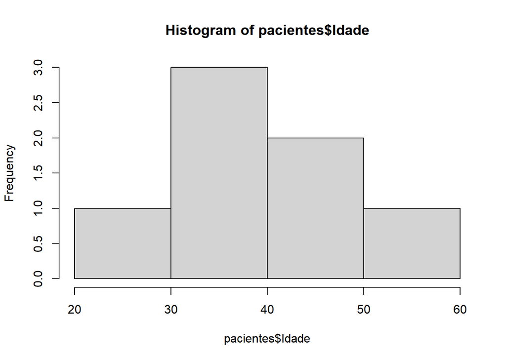

```r
hist(pacientes$Idade)
```

##### Combinando dataframes

```r
dataset_final <- merge(pesq, pacientes)
dataset_final
```

```
##         Var 1  Var 2 Var 3 Var 4    Var 5 ID       Nome Idade    Admdate
## 1    Portugal  Bruno  1.88  5001    verde  1 Paciente 1    43 15/10/2015
## 2  Inglaterra  Tiago  1.76  2183     azul  1 Paciente 1    43 15/10/2015
## 3     Irlanda Amanda  1.53  4702     azul  1 Paciente 1    43 15/10/2015
## 4       Egito Bianca  1.69  7965 castanho  1 Paciente 1    43 15/10/2015
## 5      Brasil  Marta  1.68  8890 castanho  1 Paciente 1    43 15/10/2015
## 6    Portugal  Bruno  1.88  5001    verde  2 Paciente 2    23 16/10/2015
## 7  Inglaterra  Tiago  1.76  2183     azul  2 Paciente 2    23 16/10/2015
## 8     Irlanda Amanda  1.53  4702     azul  2 Paciente 2    23 16/10/2015
## 9       Egito Bianca  1.69  7965 castanho  2 Paciente 2    23 16/10/2015
## 10     Brasil  Marta  1.68  8890 castanho  2 Paciente 2    23 16/10/2015
## 11   Portugal  Bruno  1.88  5001    verde  3 Paciente 3    56 23/10/2015
## 12 Inglaterra  Tiago  1.76  2183     azul  3 Paciente 3    56 23/10/2015
## 13    Irlanda Amanda  1.53  4702     azul  3 Paciente 3    56 23/10/2015
## 14      Egito Bianca  1.69  7965 castanho  3 Paciente 3    56 23/10/2015
```

[output cut: 57 more lines]

#### Exercício 1

Crie um vetor com 30 números inteiros

#### Exercício 4

Usando a função read.table() leia o arquivo do link abaixo para uma dataframe http://data.princeton.edu/wws509/datasets/effort.dat

# Exercício 5 - Transforme o dataframe anterior, em um dataframe nomeado com os seguintes labels:

# c(“config”, “esfc”, “chang”)

# Exercício 6 - Imprima na tela o dataframe iris, verifique quantas dimensões existem no dataframe iris e imprima um resumo do dataset

# Exercício 7 - Crie um plot simples usando as duas primeiras colunas do dataframe iris

# Exercício 8 - Usando a função subset, crie um novo dataframe com o conjunto de dados do dataframe iris em que Sepal.Length > 7

# Dica: consulte o help para aprender como usar a função subset()

# Exercícios 9 (Desafio) - Crie um dataframe que seja cópia do dataframe iris e usando a função slice(), divida o dataframe em um subset de 15 linhas

# Dica 1: Você vai ter que instalar e carregar o pacote dplyr

# Dica 2: Consulte o help para aprender como usar a função slice()

# Exercícios 10 - Use a função filter no seu novo dataframe criado no item anterior e retorne apenas valores em que Sepal.Length > 6

# Dica: Use o RSiteSearch para aprender como usar a função filter

#### Resolução de Exercícios

##### 01

```r
vec30 <- c(1:30)
vec30
```

```
##  [1]  1  2  3  4  5  6  7  8  9 10 11 12 13 14 15 16 17 18 19 20 21 22 23 24 25
## [26] 26 27 28 29 30
```

##### 02

```r
mat <- matrix(c(27:30), nr=2)
mat
```

```
##      [,1] [,2]
## [1,]   27   29
## [2,]   28   30
```

#### 03

```r
lista1 <- list(cbind(mat, matrix(vec30, nr=2)))
lista1
```

```
## [[1]]
##      [,1] [,2] [,3] [,4] [,5] [,6] [,7] [,8] [,9] [,10] [,11] [,12] [,13] [,14]
## [1,]   27   29    1    3    5    7    9   11   13    15    17    19    21    23
## [2,]   28   30    2    4    6    8   10   12   14    16    18    20    22    24
##      [,15] [,16] [,17]
## [1,]    25    27    29
## [2,]    26    28    30
```

#### 04

```r
dados1 <- read.table('http://data.princeton.edu/wws509/datasets/effort.dat')
head(dados1)
```

```
##           setting effort change
## Bolivia        46      0      1
## Brazil         74      0     10
## Chile          89     16     29
## Colombia       77     16     25
## CostaRica      84     21     29
## Cuba           89     15     40
```

```r
class(dados1)
```

```
## [1] "data.frame"
```

#### 05

```r
colnames(dados1) <- c("config", "esfc", "chang")
dados1
```

```
##                config esfc chang
## Bolivia            46    0     1
## Brazil             74    0    10
## Chile              89   16    29
## Colombia           77   16    25
## CostaRica          84   21    29
## Cuba               89   15    40
## DominicanRep       68   14    21
## Ecuador            70    6     0
## ElSalvador         60   13    13
## Guatemala          55    9     4
## Haiti              35    3     0
## Honduras           51    7     7
## Jamaica            87   23    21
## Mexico             83    4     9
## Nicaragua          68    0     7
## Panama             84   19    22
## Paraguay           74    3     6
## Peru               73    0     2
## TrinidadTobago     84   15    29
## Venezuela          91    7    11
```

#### 06

View(iris)